# 00_A_4_conditionals_forloops

# Conitionals: `if-elseif-else` statements

## General structure

A conditional statement with an `if-elseif-else` structure follows the same flowchart across multiple programming languages. For example, with 3 conditions we might have (more conditions could be added as needed):

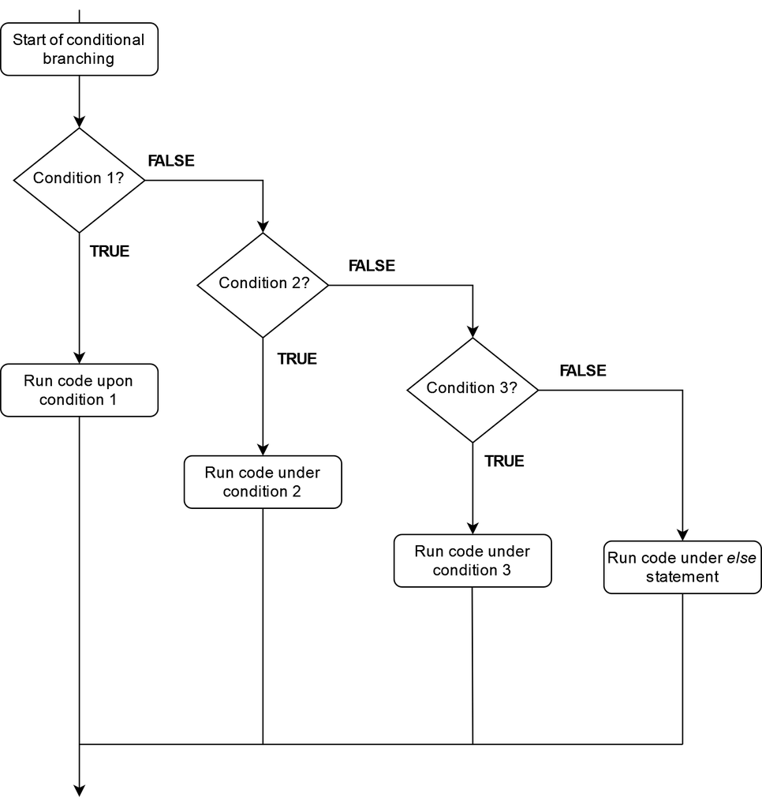

The template for that conditional statement in R is as follows:

```r
if (condition_1) {

  # Section runs if condition_1 == TRUE

}else if (condition_2){

  # Section runs if condition_2 == TRUE

}else if (condition_3){

  # Section runs if condition_3 == TRUE

}

# ... INCLUDE AS MANY else if CONDITIONS AS REQUIRED

else{

  # Section runs if
  # (condition_1 == FALSE) & (condition_2 == FALSE) & (condition_3 == FALSE)

}
```

In the above structure, please note the following:

- All the statements executed upon each condition are **bracketed** `{` `}`.
- The conditions are expressed within parenthesis `(` `)`.
- `condition_1`, `condition_2` and `condition_3` are booleans or expressions that evaluate to booleans. Recall the fundamentals about:
  - Booleans
  - The `&` (AND) and `|` (OR) operators
  - The `!` operator (logical negation)
  - The relational operators (`>`, `<`, `>=`, `<=`, `==` and `!=`)
- **All the `else if` sections as well as the `else` sections are optional**. In other words, the most succint version of the above structure would be:

```r
# Most simple version of an if statement
if (condition_1) {

  # Section runs if condition_1 == TRUE

}
```

Let us look at a basic example that executes different statements depending on whether an integer belongs to the natural numbers, the whole numbers or the integer numbers. The `cat()` function is an alternative to `print()` used in R. In the character strings used below, the special character `\n` is the *new line character*, which signals to the function `cat()` that it should start a new line. We do this to achieve more clarity on the output.

```r
# Input
integer <- # INTRODUCE USER INPUT

if (integer > 0){
  cat("Input is a greater than 0. Therefore a natural number")
}else if (integer == 0){
  cat("Input is equal to 0. Therefore a whole number")
  cat("\nWhole numbers are the set of natural numbers expanded with 0")
}else if (integer < 0){
  cat("Input is negative. Therefore an integer")
  cat("\nIntegers include whole numbers and their negative counterparts")
}

cat("\nThe program has finished")
```

If we actually run the code above with `integer <- -1L` we get the following output:

```r
# Input
integer <- -1L # L signals that number is an integer

if (integer > 0){
  cat("Input is a greater than 0. Therefore a natural number")
}else if (integer == 0){
  cat("Input is equal to 0. Therefore a whole number")
  cat("\nWhole numbers are the set of natural numbers expanded with 0")
}else if (integer < 0){
  cat("Input is negative. Therefore an integer")
  cat("\nIntegers include whole numbers and their negative counterparts")
}
```

```
Input is negative. Therefore an integer
Integers include whole numbers and their negative counterparts
```

```r
cat("\nThe program has finished")
```

```
The program has finished
```

Try running the example above with different values of the variable `integer`

## Situation with multiple `TRUE` conditions

If more than one of the conditions is `TRUE`, then only the code under the condition that first evaluates to `TRUE` is executed. For example:

```r
if (3<5){
  cat("hello")
}else if(2<3){
  cat("world")
}
```

```
hello
```

If we wanted both statements to run, we could not use and `if-else if` structure, but rather two separate `if`:

```r
if (3<5){
  cat("hello")
}
```

```
hello
```

```r
if (2<3){
  cat("\nworld") #\n is the new line character
}
```

```
world
```

## Nested if-else statements

We can nest `if... else` structures so that, within each condition, another `if... else` structure is followed. For example, in the generic example at the beginning of this notebook we may include an additional `if... else` structure:

```r
if (condition_1) {

  # Section runs if condition_1 == TRUE

}else if (condition_2){

  # Section runs if condition_2 == TRUE

  if (condition_2_1){

    # Section runs if (condition_2 == TRUE) & (condition_2_1 == TRUE)

  }else

    # Section runs if (condition_2 == TRUE) & (condition_2_1 == FALSE)

  }

  # Section runs also runs if condition_2 == TRUE

}else if (condition_3){

  # Section runs if condition_3 == TRUE

}

# ... INCLUDE AS MANY else if CONDITIONS AS REQUIRED

else{

  # Section runs if
  # (condition_1 == FALSE) & (condition_2 == FALSE) & (condition_3 == FALSE)

}
```

The example below illustrates how these nested statements work. First the code is given and then we will run the code with specific values of age an retirement age:

```r
# Input
age <- # INTRODUCE YOUR AGE
retirement_age <- # INTRODUCE YOUR COUNTRY's retirement age

if (age < 18) {
  cat("You are underage.")
  cat("\nYou are not eligible to Work")
} else {
  if (age <= retirement_age)  {
    cat("You are eligible to Work")
    cat("\nPlease fill the application form and email us")
  } else {
    cat("The government thinks you are too old to work")
    cat("\nPlease collect your pension if you are lucky enough!")
  }
}

cat("\nThe program has finished")
```

Running this for `age <- 30` and `retirement_age <- 67` results in the following:

```r
# Input
age <- 30
retirement_age <- 67

if (age < 18) {
  cat("You are underage.")
  cat("\nYou are not eligible to Work")
} else {
  if (age <= retirement_age)  {
    cat("You are eligible to Work")
    cat("\nPlease fill the application form and email us")
  } else {
    cat("The government thinks you are too old to work")
    cat("\nPlease collect your pension if you are lucky enough!")
  }
}
```

```
You are eligible to Work
Please fill the application form and email us
```

```r
cat("\nThe program has finished")
```

```
The program has finished
```

Feel free to try other values for the variables.

# For loops

The general syntax for a for loop in R is:

```r
for (val in sequence){

  # statements that execute sequentially for every value in the sequence

}

# statements executed after having iterated through all the values in sequence
```

- `sequence` is a vector. The for loop **iterates over all the values of the sequence**. This means that it executes the code within the for loop for each of the values in the vector.
- `val` stands for value. **For each iteration the variable `val` gets assigned the current vector element**.

Essentially, the code above **iterates over all the values of the sequence and executes the statements within the for loop sequentially for each value of the vector**. The execution of the statements for a specific value within the vector is called an **iteration**.

The flowchart below further clarifies this (the flowchart uses the notation `item` instead of `val`, but it is otherwise equivalent:

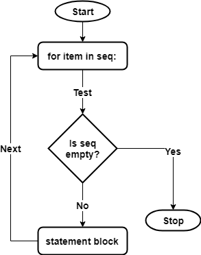

Note that `val` (or `item`) could have been given any other name. We will see this in the examples below.

## Examples with integers

The most basic example that I can think of a for loop is:

```r
for (i in seq(1, 10)){
  cat(i, "\n") # \n is the new line character
}

cat("\nThe value of i upon exiting the for loop was", i)
```

The code above does the following. For each value in `seq(1,10)` (1, 2, 3, 4, 5, 6, 7, 8, 9, 10) it runs all the code within the for loop. In this case the only code is the `cat()` statement, which prints the current value of `i`. Finally it prints the last statement, which examines the value of `i` upon exiting the for loop. Because all the iterations are executed, the value if `i` after finishing the loop is 10 (the last value in the sequence).

Let us actually run the code and check this:

```r
for (i in seq(1, 10)){
  cat(i, "\n") # \n is the new line character
}
```

```
1
2
3
4
5
6
7
8
9
10
```

```r
cat("\nThe value of i upon exiting the for loop was", i)
```

```
The value of i upon exiting the for loop was 10
```

Note that **we could have used another name for the variable `i`**. `i` was simply chosen because it is convention to do this when looping through integers. But we could have given it another name and do exactly the same. For example:

```r
for (thing in seq(1, 10)){
  cat(thing, "\n") # \n is the new line character
}
```

```
1
2
3
4
5
6
7
8
9
10
```

```r
cat("\nThe value of thing upon exiting the for loop was", thing)
```

```
The value of thing upon exiting the for loop was 10
```

The next example shows that you can have multiple statements within a for loop, not only a single statement:

```r
for (i in seq(1, 10)){
  n <- 2*i
  cat("i = ", i, ", n = ", n, "\n") # Examine the values of i and n within each iteration.
                                    # \n is the new line character.
}
```

```
i =  1 , n =  2
i =  2 , n =  4
i =  3 , n =  6
i =  4 , n =  8
i =  5 , n =  10
i =  6 , n =  12
i =  7 , n =  14
i =  8 , n =  16
i =  9 , n =  18
i =  10 , n =  20
```

## Examples with vectors of something other than integers:

The vector could contain objects other than integers. For example:

```r
for (name in c("Frodo", "Sam", "Aragorn", "Legolas", "Gimly")){
  cat(name, "\n") # \n is a special character used to signal 'new line'
}
```

```
Frodo
Sam
Aragorn
Legolas
Gimly
```

Or for example

```r
for (num in c(0.1, 0.5, 0.8, 1.74)){
  cat(num, "\n")
}
```

```
0.1
0.5
0.8
1.74
```

## Next and break

- `next`: used in situations where you need to skip the rest of the statements in a specific iteration of the for loop and go to the next iteration.
- `break`: exits the for loop entirely. That is, it exits the current iteration, does not execute any subsequent iteration and moves on to execute the code after the for loop.

The following examples will clarify the difference between `next` and `break`.

First lets check the output the very basic for loop below. The subsequent examples will alter the behavior of the for loop using `next` and `break`:

```r
for (i in seq(0, 100, by=10)){
 cat(i, "\n")
}
```

```
0
10
20
30
40
50
60
70
80
90
100
```

### Example 1 - next

```r
for (i in seq(0, 100, by=10)){
  if (i < 50){
    next
  }
 cat(i, "\n")
}
```

```
50
60
70
80
90
100
```

```r
cat("\nThe value of i upon exiting the for loop was", i)
```

```
The value of i upon exiting the for loop was 100
```

The code above skips the `cat(i, "")` statement for every value of i smaller than 50 because the `next` statement took the flow of the program to the beginning of the next iteration. In other words, only at the 6-th iteration (for which `i = 50`) the cat statement started to be executed.

### Example 2 - break

```r
for (i in seq(0, 100, by=10)){
  if (i < 50){
    break
  }
 cat(i, "\n")
}

cat("\nThe value of i upon exiting the for loop was", i)
```

```
The value of i upon exiting the for loop was 0
```

The code above does not execute any of the `cat(i, "")` statements within the loop because, during the first iteration (`i = 0`), the `break` statement is executed, exiting the for loop altogether and continuing executing the remaining statements.

### Example 3 - break

```r
for (i in seq(0, 100, by=10)){
  if (i > 50){
    break
  }
 cat(i, "")
}
```

```
0 10 20 30 40 50
```

```r
cat("\nThe value of i upon exiting the for loop was", i)
```

```
The value of i upon exiting the for loop was 60
```

Note that, upon exiting the for loop, the value of i was 60. In other words, in the 7-th iteration, `i` was assigned the value 60 and the break statement was executed, exiting the loop altogether and therefore the value if `i` right after the loop is still 60.

### Example 4 - next

```r
for (i in seq(0, 100, 10)){
  if (i > 50){
    next
  }
 cat(i, "")
}
```

```
0 10 20 30 40 50
```

```r
cat("\nThe value of i upon exiting the for loop was", i)
```

```
The value of i upon exiting the for loop was 100
```

Note that **in examples 3 and 4 the same numbers are printed when using next instead of break**. However, **there is a crucial difference**. Now the value of i at the end of the loop is 100 instead of 60. The for loop continued beyond i = 60, only the `cat(i, "")` statement skipped because at every `next` statement the flow moved to the next iteration skipping the rest of the statements in that iteration.